# Animal Tracking Toolbox Quick Guide

Vinay Udyawer, Ross Dwyer, Xavier Hoenner

Nov 28, 2018

# Background

Passive telemetry studies use detection patterns of a tagged animal within a fixed array to understand movement patterns, habitat use and activity space. Raw detection data are typically used to calculate metrics of detection (i.e. number of detections, number of days detected, number of receivers tag was detected on, index of residence), dispersal (e.g. distances and bearings between consecutive detections; step distances and turning angles, distances and bearings between each detection and release site) and activity space (e.g. Minimum Convex Polygon MCP area, Kernel Utilisation Distribution area), however the techniques and parameters used to calculate these metrics are often customised to each study making cross-study comparisons unreliable. Here we provide a tool to facilitate a standardised workflow to calculate these commonly used metrics.

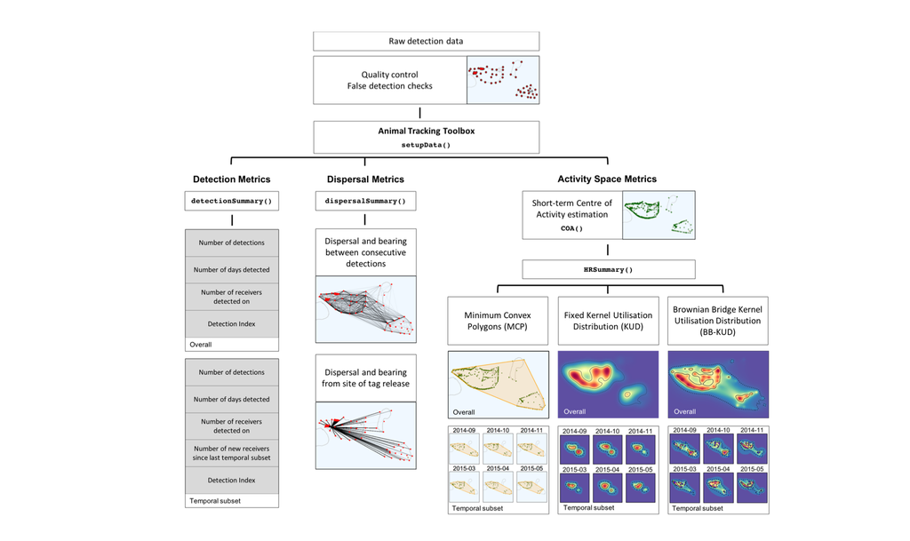

<sub>Figure 1. Visual summary of workflow to calculate standardised metrics using the Animal Tracking Toolbox.</sub>

The Animal Tracking Toolbox (ATT) is a collection of functions created in the R statistical environment (R Development Core Team 2018) that calculates standardised metrics of dispersal and activity space from passive telemetry to enable direct comparisons between animals tracked within the same study and between studies or locations. The functions uses detection data alongside tag metadata and receiver station information to calculate a range of standardised movement and activity space metrics. This toolbox can be used to calculate and visualise standardised metrics of movement and activity space within and between species tracked at multiple locations.

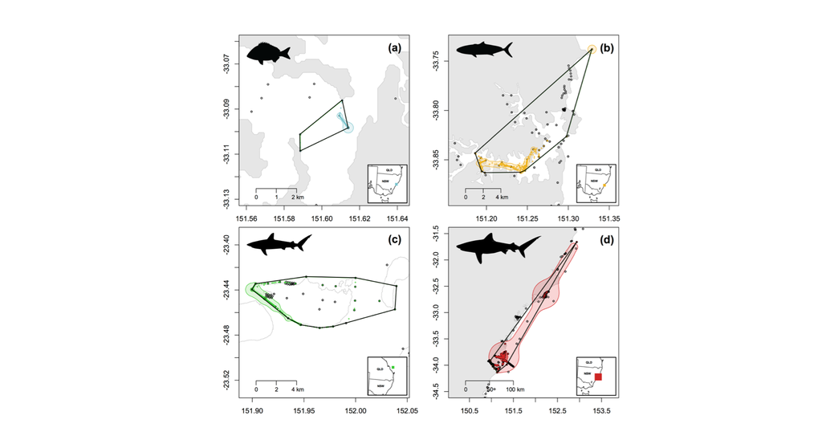

<sub>Figure 2. Overall activity space metric plots for multiple species tagged at multiple locations (a) Yellowfin Bream (n=1), (b) Yellowtail Kingfish (n=1), (c) Grey Reef Shark (n=1) and (d) Bull Shark (n=1) output using the ATT. Coloured points represent Centres of Activity (60 min time steps) with darker shapes representing core activity space (50% contour of Brownian bridge kernel utilisation distribution; BBKUD) and lighter shapes representing the extent of activity space (95% contour of BBKUD). Black polygons represent overall Minimum Convex Polygons from detection data. Open circles represent locations of VR2W receivers deployed within the IMOS ATF infrastructure and associated research installations.</sub>

The ATT was developed to preprocess and calculate standardised metrics of dispersal and activity space from large-scale detection data housed in the Integrated Marine Observing System’s Animal Tracking Facility (IMOS ATF) national data repository. The ATT accepts detection data exported from the IMOS ATF database (referred to as `IMOSdata` here, and can be accessed through the [AODN portal](https://portal.aodn.org.au)). The ATT can also be used to analyse data exported from the VEMCO data management software VUE (refered to as `VEMCOdata` here). We are currently working on additional functionality for using the ATT with detection data exported from other passive telemetry networks.

This manual will outline the required data formats for input tag detection data (either `IMOSdata` or `VEMCOdata`), associated tag metadata (referred to as `taginfo` ) and receiver station information (`statinfo`). This manual will also demonstrate how to run the function for a single tag as well as running the function for a large number of tags.

# Installation

Currently the development version can be accessed from GitHub:

```r
install.packages("devtools")
devtools::install_github("vinayudyawer/ATT")
```

The Animal Tracking Toolbox will be eventually integrated into the ‘VTrack’ package.

# Functions within the toolbox

In addition to these functions, there are additional functions to help plot detection summaries using an abacus plot (**`abacusPlot()`**). We are working on more functions to help visualise dispersal summaries and activity spaces calculated… Watch this space!!

# Input data formats

Analysing passive telemetry data requires three sets of data: Tag detection data (refered to here as either `IMOSdata` or `VEMCOdata`, depending on data source); Tag metadata (`taginfo`); and Receiver metadata (`statinfo`). The ATT was developed to recognise field names from the IMOS ATF database and more generally from a VEMCO VUE database that is commonly used in the field of passive acoustic telemetry. These data formats are detailed below, and can be used as a guide to configure the tag detection data input if the VEMCO or IMOS ATF data formats are not used. The `taginfo` and `statinfo` data formats conforms to the metadata information stored on the IMOS ATF database, and similar formats should be used to store metadata information on animals tagged for analysing passive acoustic telemetry data.

## Tag detection data formats

### VEMCO input format (`VEMCOdata`)

| Data field | Description | Required field? |
| --- | --- | --- |
| Date and Time (UTC) | Date and time of tag detection (yyyy-mm-dd HH:MM:SS) | Yes |
| Receiver | Name of acoustic receiver, combines receiver model with its serial number (e.g. VR2W-123456) | Yes |
| Transmitter | Combination of code map and ping ID (eg. A69-1303-14503) | Yes |
| Sensor Value | Physical measurement recorded by a tag’s sensor, if applicable (If sensor data hasn’t been converted then sensor_unit = ‘ADC’ and values range from 0 to 255.) | Yes |
| Sensor Unit | Physical unit associated with sensor values (Either ‘ADC’, ‘°C’, ‘m’ or ‘m/s2’) | Yes |
| Station Name | Name of receiving station on which the transmitter was detected. Acoustic receivers typically gets deployed multiple times at the same station | Yes |
| Latitude | Latitude at which receiver was deployed and tag was detected (d.ddd˚) | Yes |
| Longitude | Longitude at which receiver was deployed and tag was detected (d.ddd˚) | Yes |
| Transmitter Name | Ping ID of transmitter deployed (e.g. 14503) | No |
| Transmitter Serial | Manufacturers serial number for deployed transmitter (e.g. 1126413) | No |

### IMOS ATF input format (`IMOSdata`)

| Data field | Description | Required field? |
| --- | --- | --- |
| transmitter_id | Combination of code map and ping ID. Dual sensor tags are associated with multiple transmitter IDs (e.g. A69-9002-12345) | Yes |
| station_name | Name of receiving station on which the transmitter was detected. Acoustic receivers typically gets deployed multiple times at the same station | Yes |
| receiver_name | Name of acoustic receiver, combines receiver model with its serial number (e.g. VR2W-123456) | Yes |
| detection_timestamp | Date and time of tag detection (yyyy-mm-dd HH:MM:SS) | Yes |
| longitude | Longitude at which receiver was deployed and tag was detected (d.ddd˚) | Yes |
| latitude | Latitude at which receiver was deployed and tag was detected (d.ddd˚) | Yes |
| sensor_value | Physical measurement recorded by a tag’s sensor, if applicable (If sensor data hasn’t been converted then sensor_unit = ‘ADC’ and values range from 0 to 255.) | Yes |
| sensor_unit | Physical unit associated with sensor values (Either ‘ADC’, ‘°C’, ‘m’ or ‘m/s2’) | Yes |
| installation_name | Name of installation on which the transmitter was detected. An installation typically consists of multiple receiving stations | No |
| FDA_QC | Quality control flag for the false detection algorithm (1:passed, 2:failed) | No |
| Velocity_QC | Velocity from previous and next detections both 10 m.s-1? (1:yes, 2:no) | No |
| Distance_QC | Distance from previous and next detections both < 1000 km? (1:yes, 2:no) | No |
| DetectionDistribution_QC | Detection occurred within expert distribution area? (1:yes, 2:no, 3:test not performed) | No |
| DistanceRelease_QC | Detection occurred within 500 km of release location? (1:yes, 2:no) | No |
| ReleaseDate_QC | Detection occurred before the tag release date? (1:yes, 2:no) | No |
| ReleaseLocation_QC | Tag release lat/long coordinates within expert distribution area and/or within 500 km from first detection? (1:yes, 2:no) | No |
| Detection_QC | Composite detection flag indicating the likely validity of detections (1:valid detection, 2:probably valid detection, 3:probably bad detection, 4:bad detection) | No |

## Tag metadata input format (`taginfo`)

Tag metadata input format is based on IMOS ATF metadata structure

| Data field | Description | Required field? |
| --- | --- | --- |
| tag_id | Unique tag ID. Dual sensor tags will have different transmitter IDs but the same tag ID. This field is to ensure tags are associated with animals. Can include a character vector or numeric (e.g. “Tigg… | Yes |
| transmitter_id | Combination of code map and ping ID (e.g. . A69-9002-12345) | Yes |
| scientific_name | Tagged species scientific name | Yes |
| common_name | Tagged species common name | Yes |
| tag_project_name | Project name under which a tag was registered | Yes |
| release_id | Unique tag release ID. A given tag ID may be associated with several release IDs if it has been re-deployed. | Yes |
| release_latitude | Latitude at which tag was deployed (d.ddd˚) | Yes |
| release_longitude | Longitude at which tag was deployed (d.ddd˚ | Yes |
| ReleaseDate | Date and time at which tag was deployed (yyyy-mm-dd HH:MM:SS) | Yes |
| tag_expected_life_time_days | Tag expected life time (days) | Yes |
| tag_status | Tag status (e.g. deployed, lost, etc) | Yes |
| sex | Sex of tagged animal (if recorded) | Yes |
| measurement | Morphometric information of tagged animal (if recorded; e.g. Total length, weight) | Yes |
| sensor_slope | Slope used in the linear equation to convert raw sensor measurements | No |
| sensor_intercept | Intercept used in the linear equation to convert raw sensor measurements | No |
| sensor_type | Type of sensor (Can be pinger, temperature, pressure, or accelerometer) | No |
| sensor_unit | Physical unit associated with sensor values (Either ‘ADC’, ‘°C’, ‘m’ or ‘m/s2’) | No |
| tag_model_name | Tag model (e.g. V9, V13-TP, V16-P, V9-A) | No |
| tag_serial_number | Manufacturers serial number for deployed transmitter (e.g. 1126413) | No |
| dual_sensor_tag | Is the tag a dual sensor tag (TRUE/FALSE) | No |

## Receiver metadata input format (`statinfo`)

Receiver metadata input format is based on IMOS ATF metadata structure

| Data field | Description | Required field? |
| --- | --- | --- |
| station_name | Name of receiving station. Acoustic receivers typically gets deployed multiple times at the same station. Station name will be used to differentiate reciever stations rather than Receiver serial numbe… | Yes |
| receiver_name | Name of acoustic receiver, combines receiver model with its serial number (e.g. VR2W-123456) | Yes |
| installation_name | Name of installation of which receiver is part of. An installation typically consists of multiple receiving stations | Yes |
| project_name | Project name under which the receiver was registered under | Yes |
| deploymentdatetime_timestamp | Date and time at which receiver was deployed (yyyy-mm-dd HH:MM:SS) | Yes |
| recoverydatetime_timestamp | Date and time at which receiver was recovered/removed (yyyy-mm-dd HH:MM:SS) | Yes |
| station_latitude | Latitude at which receiver was deployed (d.ddd˚) | Yes |
| station_longitude | Longitude at which receiver was deployed (d.ddd˚) | Yes |
| status | Status of receiver (e.g. deployed, lost, damaged, recovered, etc) | Yes |

# Usage

**Load the ATT library**

```ruby
library(ATT)
```

**Setup data for smooth functioning with other ATT functions**

```ruby
## Input example datasets
data(IMOSdata)  ## Detection data exported from IMOS data repository
data(VEMCOdata) ## Detection data exported from a VUE database
data(taginfo)
data(statinfo)

## Setup data for use with the Animal Tracking Toolbox
ATTdata<- setupData(Tag.Detections = IMOSdata,
                    Tag.Metadata = taginfo,
                    Station.Information = statinfo,
                    source="IMOS")
```

**Calculating detection metrics**

```ruby
## Calculate detecion metrics with monthly subsets chosen
detSum<-detectionSummary(ATTdata,
                         sub = "%Y-%m")
```

`detectionSummary()` outputs a list object with two components, `$Overall`: detection metrics for the full period of the tag and `$Subsetted`: detection metrics for weekly or monthly temporal subsets depending on the `sub` argument.

```ruby
detSum
$Overall
# A tibble: 11 x 10
    Tag.ID Transmitt… Sci.Name Sex   Bio   Number.of.Detec… Number.of.Stati… Days.Detected Days.at.Liberty
     <int> <fct>      <fct>    <fct> <fct>            <int>            <int>         <int>           <dbl>
 1  4.46e6 A69-1303-… Galeoce… FEMA… NA                   9                4             1             858
 2  5.14e7 A69-9002-… Galeoce… FEMA… FORK…              765               43            82             828
 3  5.14e7 A69-9002-… Galeoce… FEMA… NA                1134               45            64             824
 4  5.14e7 A69-9002-… Galeoce… FEMA… FORK…            16867               30           591             834
 5  5.14e7 A69-9002-… Galeoce… FEMA… FORK…               27                3             2             825
 6  5.14e7 A69-9002-… Galeoce… FEMA… FORK…             2679               39           133             824
 7  5.14e7 A69-9002-… Galeoce… FEMA… FORK…            10386               50           507             824
 8  7.75e7 A69-9002-… Galeoce… FEMA… TOTA…            12988               46           649             832
 9  7.75e7 A69-9002-… Galeoce… FEMA… TOTA…             2706               60           286             832
10  7.75e7 A69-9002-… Galeoce… FEMA… TOTA…            14592               56           742             846
11  7.75e7 A69-9002-… Galeoce… FEMA… TOTA…            16600               71           739             835
# ... with 1 more variable: Detection.Index <dbl>

$Subsetted
# A tibble: 197 x 12
    Tag.ID subset  Transmitt…  Sci.Name   Sex   Bio       Number.of.Detect… Number.of.Stati… Days.Detected
     <int> <fct>   <fct>       <fct>      <fct> <fct>                 <int>            <int>         <int>
 1  4.46e6 2012-12 A69-1303-6… Galeocerd… FEMA… NA                        9                4             1
 2  5.14e7 2012-09 A69-9002-1… Galeocerd… FEMA… FORK LEN…                 1                1             1
 3  5.14e7 2013-04 A69-9002-1… Galeocerd… FEMA… FORK LEN…                14                3             1
 4  5.14e7 2013-06 A69-9002-1… Galeocerd… FEMA… FORK LEN…                63               14             5
 5  5.14e7 2013-07 A69-9002-1… Galeocerd… FEMA… FORK LEN…               154               29            17
 6  5.14e7 2013-08 A69-9002-1… Galeocerd… FEMA… FORK LEN…               113               26            17
 7  5.14e7 2013-10 A69-9002-1… Galeocerd… FEMA… FORK LEN…                16                6             3
 8  5.14e7 2014-02 A69-9002-1… Galeocerd… FEMA… FORK LEN…                 8                2             1
 9  5.14e7 2014-04 A69-9002-1… Galeocerd… FEMA… FORK LEN…                 4                2             1
10  5.14e7 2014-06 A69-9002-1… Galeocerd… FEMA… FORK LEN…               123               15             9
# ... with 187 more rows, and 3 more variables: New.Stations <int>, Days.at.Liberty <int>,
#   Detection.Index <dbl>

## Accessing metrics of detection for full tag life
detSum$Overall

## Accessing metrics of detection for each temporal subset
detSum$Subsetted
```

**Create an abacus plot**

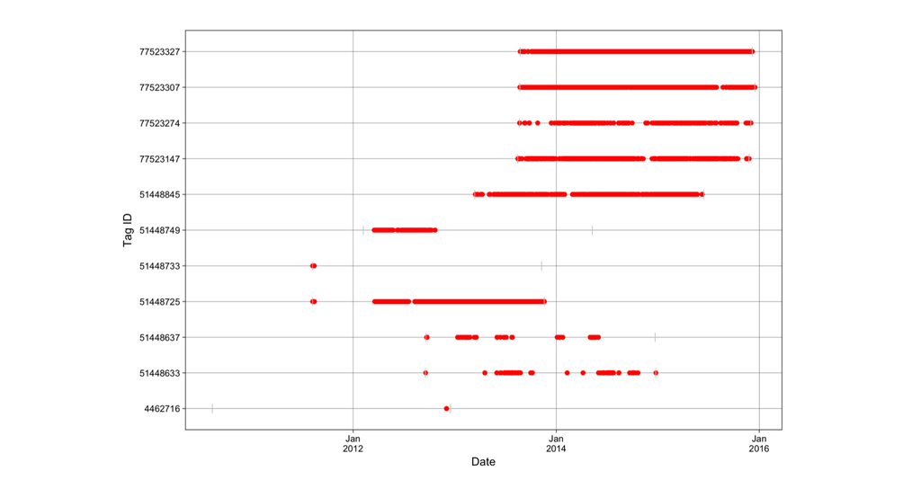

```ruby
abacusPlot(ATTdata)
```

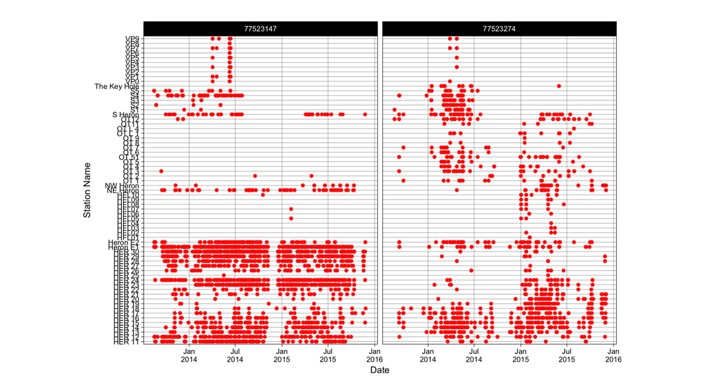

```ruby
## Create a facetted abacus plot for individuals 77523274 and 77523147
abacusPlot(ATTdata,
           id=c("77523274","77523147"),
           facet=TRUE)
```

**Calculating dispersal metrics**

```ruby
## Calculate dispersal metrics
dispSum<-dispersalSummary(ATTdata)
```

`dispersalSummary()` outputs a tibble data frame object with step distances and step bearings calculated for each detection. The number of rows will be equal to the raw detection data, therefore it may take longer to process dispersal metrics for a large number of animals or for large datasets.

```ruby
## Accessing metrics of dispersal
dispSum
# A tibble: 78,753 x 24
   Date.Time           Transmitter    Station.Name Receiver    Latitude Longitude Sensor.Value Sensor.Unit
   <dttm>              <fct>          <fct>        <fct>          <dbl>     <dbl>        <int> <fct>
 1 2012-12-02 17:24:12 A69-1303-64957 OT 7         VR2W-114582    -23.5      152.           NA NA
 2 2012-12-02 18:08:14 A69-1303-64957 OT 6         VR2W-114539    -23.5      152.           NA NA
 3 2012-12-02 18:21:28 A69-1303-64957 The Key Hole VR2W-114555    -23.5      152.           NA NA
 4 2012-12-02 18:22:19 A69-1303-64957 The Key Hole VR2W-114555    -23.5      152.           NA NA
 5 2012-12-02 18:23:16 A69-1303-64957 The Key Hole VR2W-114555    -23.5      152.           NA NA
 6 2012-12-02 18:24:27 A69-1303-64957 The Key Hole VR2W-114555    -23.5      152.           NA NA
 7 2012-12-02 18:25:25 A69-1303-64957 The Key Hole VR2W-114555    -23.5      152.           NA NA
 8 2012-12-02 19:01:59 A69-1303-64957 OT 5         VR2W-101787    -23.5      152.           NA NA
 9 2012-12-02 19:02:50 A69-1303-64957 OT 5         VR2W-101787    -23.5      152.           NA NA
10 2012-09-18 20:26:14 A69-9002-14797 Heron E1     VR2W-114577    -23.4      152.            6 ADC
# ... with 78,743 more rows, and 16 more variables: Tag.ID <int>, Sci.Name <fct>, Common.Name <fct>,
#   Tag.Project <fct>, Release.Latitude <dbl>, Release.Longitude <dbl>, Release.Date <date>,
#   Tag.Life <int>, Tag.Status <fct>, Sex <fct>, Bio <fct>, Release.Dispersal <dbl>,
#   Release.Bearing <dbl>, Consecutive.Dispersal <dbl>, Consecutive.Bearing <dbl>,
#   Time.Since.Last.Detection <dbl>
```